# Identify_Customer_Segments

### Prerequsite - Scikit Learn

With scikit-learn 0.24.x. or newer, we can use this [OneHotEncoder](https://scikit-learn.org/0.21/modules/generated/sklearn.preprocessing.OneHotEncoder.html) library.

```python
import sklearn
print('The scikit-learn version is {}.'.format(sklearn.__version__))
```

```
The scikit-learn version is 1.6.1.
```

```python
# Import and use OneHotEncoder
from sklearn.preprocessing import OneHotEncoder
```

# Project: Identify Customer Segments

In this project, we will apply unsupervised learning techniques to identify segments of the population that form the core customer base for a mail-order sales company in Germany. These segments can then be used to direct marketing campaigns towards audiences that will have the highest expected rate of returns. The data that we will use has been provided by our partners at Bertelsmann Arvato Analytics, and represents a real-life data science task.

This notebook will help us complete this task by providing a framework within which we will perform our analysis steps. In each step of the project, we will see some text describing the subtask that we will perform, followed by one or more code cells for us to complete our work. **Feel free to add additional code and markdown cells as we go along so that we can explore everything in precise chunks.** The code cells provided in the base template will outline only the major tasks, and will usually not be enough to cover all of the minor tasks that comprise it.

It should be noted that while there will be precise guidelines on how we should handle certain tasks in the project, there will also be places where an exact specification is not provided. **There will be times in the project where we will need to make and justify our own decisions on how to treat the data.** These are places where there may not be only one way to handle the data. In real-life tasks, there may be many valid ways to approach an analysis task. One of the most important things we can do is clearly document our approach so that other scientists can understand the decisions we've made.

```python
# import libraries here; add more as necessary
import numpy as np
import pandas as pd
import matplotlib.pyplot as plt
import seaborn as sns

pd.options.display.max_rows = 10
pd.options.display.max_columns = None
```

### Step 0: Load the Data

Each row of the demographics files represents a single person, but also includes information outside of individuals, including information about their household, building, and neighborhood. We will use this information to cluster the general population into groups with similar demographic properties. Then, we will see how the people in the customers dataset fit into those created clusters. The hope here is that certain clusters are over-represented in the customers data, as compared to the general population; those over-represented clusters will be assumed to be part of the core userbase. This information can then be used for further applications, such as targeting for a marketing campaign.

To start off with, load in the demographics data for the general population into a pandas DataFrame, and do the same for the feature attributes summary. Note for all of the `.csv` data files in this project: they're semicolon (`;`) delimited. Also, considering the size of the main dataset, it may take some time for it to load completely.

```python
# Load in the general demographics data.
azdias = pd.read_csv('Udacity_AZDIAS_Subset.csv', sep=';')
# Load in the feature summary file.
features = pd.read_csv('AZDIAS_Feature_Summary.csv', sep=';')
```

```python
# Check the structure of the data after it's loaded (e.g. print the number of rows and columns, print the first few rows).
azdias.head()
```

|  | AGER_TYP | ALTERSKATEGORIE_GROB | ANREDE_KZ | CJT_GESAMTTYP | FINANZ_MINIMALIST | FINANZ_SPARER | FINANZ_VORSORGER | FINANZ_ANLEGER | FINANZ_UNAUFFAELLIGER | FINANZ_HAUSBAUER | FINANZTYP | GEBURTSJAHR | GFK_URLAUBERTYP | GREEN_AVANTGARDE | HEALTH_TYP | LP_LEBENSPHASE_FEIN | LP_LEBENSPHASE_GROB | LP_FAMILIE_FEIN | LP_FAMILIE_GROB | LP_STATUS_FEIN | LP_STATUS_GROB | NATIONALITAET_KZ | PRAEGENDE_JUGENDJAHRE | RETOURTYP_BK_S | SEMIO_SOZ | SEMIO_FAM | SEMIO_REL | SEMIO_MAT | SEMIO_VERT | … |
| --- | --- | --- | --- | --- | --- | --- | --- | --- | --- | --- | --- | --- | --- | --- | --- | --- | --- | --- | --- | --- | --- | --- | --- | --- | --- | --- | --- | --- | --- | --- |
| 0 | -1 | 2 | 1 | 2.0 | 3 | 4 | 3 | 5 | 5 | 3 | 4 | 0 | 10.0 | 0 | -1 | 15.0 | 4.0 | 2.0 | 2.0 | 1.0 | 1.0 | 0 | 0 | 5.0 | 2 | 6 | 7 | 5 | 1 | … |
| 1 | -1 | 1 | 2 | 5.0 | 1 | 5 | 2 | 5 | 4 | 5 | 1 | 1996 | 10.0 | 0 | 3 | 21.0 | 6.0 | 5.0 | 3.0 | 2.0 | 1.0 | 1 | 14 | 1.0 | 5 | 4 | 4 | 3 | 1 | … |
| 2 | -1 | 3 | 2 | 3.0 | 1 | 4 | 1 | 2 | 3 | 5 | 1 | 1979 | 10.0 | 1 | 3 | 3.0 | 1.0 | 1.0 | 1.0 | 3.0 | 2.0 | 1 | 15 | 3.0 | 4 | 1 | 3 | 3 | 4 | … |
| 3 | 2 | 4 | 2 | 2.0 | 4 | 2 | 5 | 2 | 1 | 2 | 6 | 1957 | 1.0 | 0 | 2 | 0.0 | 0.0 | 0.0 | 0.0 | 9.0 | 4.0 | 1 | 8 | 2.0 | 5 | 1 | 2 | 1 | 4 | … |
| 4 | -1 | 3 | 1 | 5.0 | 4 | 3 | 4 | 1 | 3 | 2 | 5 | 1963 | 5.0 | 0 | 3 | 32.0 | 10.0 | 10.0 | 5.0 | 3.0 | 2.0 | 1 | 8 | 5.0 | 6 | 4 | 4 | 2 | 7 | … |

```python
azdias.shape
```

```
(891221, 85)
```

```python
features.head()
```

|  | attribute | information_level | type | missing_or_unknown |
| --- | --- | --- | --- | --- |
| 0 | AGER_TYP | person | categorical | [-1,0] |
| 1 | ALTERSKATEGORIE_GROB | person | ordinal | [-1,0,9] |
| 2 | ANREDE_KZ | person | categorical | [-1,0] |
| 3 | CJT_GESAMTTYP | person | categorical | [0] |
| 4 | FINANZ_MINIMALIST | person | ordinal | [-1] |

```python
features.info()
```

```
<class 'pandas.core.frame.DataFrame'>
RangeIndex: 85 entries, 0 to 84
Data columns (total 4 columns):
 #   Column              Non-Null Count  Dtype
---  ------              --------------  -----
 0   attribute           85 non-null     object
 1   information_level   85 non-null     object
 2   type                85 non-null     object
 3   missing_or_unknown  85 non-null     object
dtypes: object(4)
memory usage: 2.8+ KB
```

## Step 1: Preprocessing

### Step 1.1: Assess Missing Data

The feature summary file contains a summary of properties for each demographics data column. We will use this file to help make cleaning decisions during this stage of the project. First of all, we should assess the demographics data in terms of missing data.

#### Step 1.1.1: Convert Missing Value Codes to NaNs

The fourth column of the feature attributes summary (loaded in above as `feat_info`) documents the codes from the data dictionary that indicate missing or unknown data. While the file encodes this as a list (e.g. `[-1,0]`), this will get read in as a string object. We'll need to do a little bit of parsing to make use of it to identify and clean the data. Convert data that matches a 'missing' or 'unknown' value code into a numpy NaN value. We might want to see how much data takes on a 'missing' or 'unknown' code, and how much data is naturally missing, as a point of interest.

```python
# Identify missing or unknown data value codes
features['missing_or_unknown'].value_counts()
```

```
missing_or_unknown
[-1]        26
[-1,9]      17
[-1,0]      16
[0]         12
[]          10
[-1,0,9]     1
[-1,X]       1
[XX]         1
[-1,XX]      1
Name: count, dtype: int64
```

```python
# Observe how much data is naturally missing
na_counts = azdias.isna().sum()
na_counts = na_counts[na_counts > 0]
na_counts
```

```
CJT_GESAMTTYP            4854
GFK_URLAUBERTYP          4854
LP_LEBENSPHASE_FEIN      4854
LP_LEBENSPHASE_GROB      4854
LP_FAMILIE_FEIN          4854
                        ...
PLZ8_HHZ               116515
PLZ8_GBZ               116515
ARBEIT                  97216
ORTSGR_KLS9             97216
RELAT_AB                97216
Length: 53, dtype: int64
```

```python
features[['attribute','missing_or_unknown']]
```

|  | attribute | missing_or_unknown |
| --- | --- | --- |
| 0 | AGER_TYP | [-1,0] |
| 1 | ALTERSKATEGORIE_GROB | [-1,0,9] |
| 2 | ANREDE_KZ | [-1,0] |
| 3 | CJT_GESAMTTYP | [0] |
| 4 | FINANZ_MINIMALIST | [-1] |
| ... | ... | ... |
| 80 | PLZ8_HHZ | [-1] |
| 81 | PLZ8_GBZ | [-1] |
| 82 | ARBEIT | [-1,9] |
| 83 | ORTSGR_KLS9 | [-1,0] |
| 84 | RELAT_AB | [-1,9] |

85 rows × 2 columns

```python
# Create copies of the raw datasets
features_cleaned = features.copy()
azdias_cleaned = azdias.copy()
```

```python
# Parsing the string values to lists
features_cleaned['missing_or_unknown'] = features_cleaned['missing_or_unknown'].apply(lambda x: x.strip('[]').split(','))
# Convert numeric strings to integers
features_cleaned['missing_or_unknown'] = features_cleaned['missing_or_unknown'].apply(lambda x: [int(code) if code.lstrip('-').isdigit() else code for code in x])
```

```python
# Check the data type of missing value codes to make sure numeric codes are integers
print(features_cleaned.loc[0,'missing_or_unknown'])
for i in features_cleaned.loc[0,'missing_or_unknown']:
    print(f'{i}: {type(i)}')
print(features_cleaned.loc[59,'missing_or_unknown'])
for i in features_cleaned.loc[59,'missing_or_unknown']:
    print(f'{i}: {type(i)}')
```

```
[-1, 0]
-1: <class 'int'>
0: <class 'int'>
[-1, 'XX']
-1: <class 'int'>
XX: <class 'str'>
```

```python
# Convert data that matches a 'missing' or 'unknown' value code into a numpy NaN value
for row in range(len(features_cleaned)):
    column = features_cleaned.loc[row,'attribute']  # Column name
    missing_codes = features_cleaned.loc[row,'missing_or_unknown']  # List of missing codes for the column
    # Convert those specific values to NaN in the 'azdias_cleaned' dataframe
    if missing_codes:  # Only apply if there are missing codes
        for code in missing_codes:
            azdias_cleaned[column] = azdias_cleaned[column].replace(code, np.nan)
```

```python
# Before converting 'missing' or 'unknown' value codes to NaN
azdias.head()
```

|  | AGER_TYP | ALTERSKATEGORIE_GROB | ANREDE_KZ | CJT_GESAMTTYP | FINANZ_MINIMALIST | FINANZ_SPARER | FINANZ_VORSORGER | FINANZ_ANLEGER | FINANZ_UNAUFFAELLIGER | FINANZ_HAUSBAUER | FINANZTYP | GEBURTSJAHR | GFK_URLAUBERTYP | GREEN_AVANTGARDE | HEALTH_TYP | LP_LEBENSPHASE_FEIN | LP_LEBENSPHASE_GROB | LP_FAMILIE_FEIN | LP_FAMILIE_GROB | LP_STATUS_FEIN | LP_STATUS_GROB | NATIONALITAET_KZ | PRAEGENDE_JUGENDJAHRE | RETOURTYP_BK_S | SEMIO_SOZ | SEMIO_FAM | SEMIO_REL | SEMIO_MAT | SEMIO_VERT | … |
| --- | --- | --- | --- | --- | --- | --- | --- | --- | --- | --- | --- | --- | --- | --- | --- | --- | --- | --- | --- | --- | --- | --- | --- | --- | --- | --- | --- | --- | --- | --- |
| 0 | -1 | 2 | 1 | 2.0 | 3 | 4 | 3 | 5 | 5 | 3 | 4 | 0 | 10.0 | 0 | -1 | 15.0 | 4.0 | 2.0 | 2.0 | 1.0 | 1.0 | 0 | 0 | 5.0 | 2 | 6 | 7 | 5 | 1 | … |
| 1 | -1 | 1 | 2 | 5.0 | 1 | 5 | 2 | 5 | 4 | 5 | 1 | 1996 | 10.0 | 0 | 3 | 21.0 | 6.0 | 5.0 | 3.0 | 2.0 | 1.0 | 1 | 14 | 1.0 | 5 | 4 | 4 | 3 | 1 | … |
| 2 | -1 | 3 | 2 | 3.0 | 1 | 4 | 1 | 2 | 3 | 5 | 1 | 1979 | 10.0 | 1 | 3 | 3.0 | 1.0 | 1.0 | 1.0 | 3.0 | 2.0 | 1 | 15 | 3.0 | 4 | 1 | 3 | 3 | 4 | … |
| 3 | 2 | 4 | 2 | 2.0 | 4 | 2 | 5 | 2 | 1 | 2 | 6 | 1957 | 1.0 | 0 | 2 | 0.0 | 0.0 | 0.0 | 0.0 | 9.0 | 4.0 | 1 | 8 | 2.0 | 5 | 1 | 2 | 1 | 4 | … |
| 4 | -1 | 3 | 1 | 5.0 | 4 | 3 | 4 | 1 | 3 | 2 | 5 | 1963 | 5.0 | 0 | 3 | 32.0 | 10.0 | 10.0 | 5.0 | 3.0 | 2.0 | 1 | 8 | 5.0 | 6 | 4 | 4 | 2 | 7 | … |

```python
# After converting 'missing' or 'unknown' value codes to NaN
azdias_cleaned.head()
```

|  | AGER_TYP | ALTERSKATEGORIE_GROB | ANREDE_KZ | CJT_GESAMTTYP | FINANZ_MINIMALIST | FINANZ_SPARER | FINANZ_VORSORGER | FINANZ_ANLEGER | FINANZ_UNAUFFAELLIGER | FINANZ_HAUSBAUER | FINANZTYP | GEBURTSJAHR | GFK_URLAUBERTYP | GREEN_AVANTGARDE | HEALTH_TYP | LP_LEBENSPHASE_FEIN | LP_LEBENSPHASE_GROB | LP_FAMILIE_FEIN | LP_FAMILIE_GROB | LP_STATUS_FEIN | LP_STATUS_GROB | NATIONALITAET_KZ | PRAEGENDE_JUGENDJAHRE | RETOURTYP_BK_S | SEMIO_SOZ | SEMIO_FAM | SEMIO_REL | SEMIO_MAT | SEMIO_VERT | … |
| --- | --- | --- | --- | --- | --- | --- | --- | --- | --- | --- | --- | --- | --- | --- | --- | --- | --- | --- | --- | --- | --- | --- | --- | --- | --- | --- | --- | --- | --- | --- |
| 0 | NaN | 2.0 | 1 | 2.0 | 3 | 4 | 3 | 5 | 5 | 3 | 4 | NaN | 10.0 | 0 | NaN | 15.0 | 4.0 | 2.0 | 2.0 | 1.0 | 1.0 | NaN | NaN | 5.0 | 2 | 6 | 7 | 5 | 1 | … |
| 1 | NaN | 1.0 | 2 | 5.0 | 1 | 5 | 2 | 5 | 4 | 5 | 1 | 1996.0 | 10.0 | 0 | 3.0 | 21.0 | 6.0 | 5.0 | 3.0 | 2.0 | 1.0 | 1.0 | 14.0 | 1.0 | 5 | 4 | 4 | 3 | 1 | … |
| 2 | NaN | 3.0 | 2 | 3.0 | 1 | 4 | 1 | 2 | 3 | 5 | 1 | 1979.0 | 10.0 | 1 | 3.0 | 3.0 | 1.0 | 1.0 | 1.0 | 3.0 | 2.0 | 1.0 | 15.0 | 3.0 | 4 | 1 | 3 | 3 | 4 | … |
| 3 | 2.0 | 4.0 | 2 | 2.0 | 4 | 2 | 5 | 2 | 1 | 2 | 6 | 1957.0 | 1.0 | 0 | 2.0 | NaN | NaN | NaN | NaN | 9.0 | 4.0 | 1.0 | 8.0 | 2.0 | 5 | 1 | 2 | 1 | 4 | … |
| 4 | NaN | 3.0 | 1 | 5.0 | 4 | 3 | 4 | 1 | 3 | 2 | 5 | 1963.0 | 5.0 | 0 | 3.0 | 32.0 | 10.0 | 10.0 | 5.0 | 3.0 | 2.0 | 1.0 | 8.0 | 5.0 | 6 | 4 | 4 | 2 | 7 | … |

```python
# Convert object type columns that have valid numeric values and previously contained 'X' or 'XX' as missing values to a numeric type
# Identify columns names
x_cols = azdias.columns[azdias.isin(['X','XX']).any()]
# Convert columns that have valid numeric values
for col in x_cols:
    old_type = azdias_cleaned[col].dtype
    azdias_cleaned[col] = pd.to_numeric(azdias_cleaned[col], errors='coerce') # Columns with mixed values are ignored
    new_type = azdias_cleaned[col].dtype
    print(f'Converted {col} from {old_type} to {new_type}')
```

```
Converted CAMEO_DEUG_2015 from object to float64
Converted CAMEO_DEU_2015 from object to float64
Converted CAMEO_INTL_2015 from object to float64
```

#### Step 1.1.2: Assess Missing Data in Each Column

There are a few columns that are outliers in terms of the proportion of values that are missing. We will use matplotlib's [`hist()`](https://matplotlib.org/api/_as_gen/matplotlib.pyplot.hist.html) function to visualize the distribution of missing value counts to find these columns. While some of these columns might have justifications for keeping or re-encoding the data, for this project we should just remove them from the dataframe.

For the remaining features, are there any patterns in which columns have, or share, missing data?

```python
# Perform an assessment of how much missing data there is in each column of the dataset.
# Count the number of missing data in each column
col_na_counts = azdias_cleaned.isna().sum()
col_na_counts
```

```
AGER_TYP                685843
ALTERSKATEGORIE_GROB      2881
ANREDE_KZ                    0
CJT_GESAMTTYP             4854
FINANZ_MINIMALIST            0
                         ...
PLZ8_HHZ                116515
PLZ8_GBZ                116515
ARBEIT                   97375
ORTSGR_KLS9              97274
RELAT_AB                 97375
Length: 85, dtype: int64
```

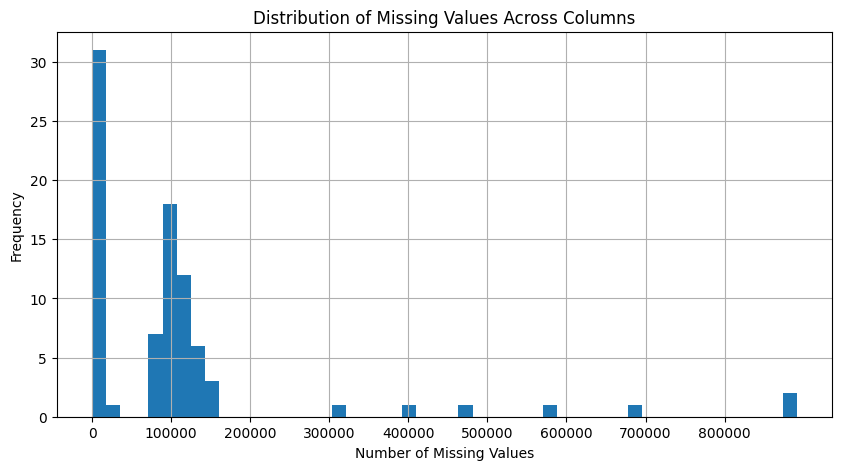

```python
# Investigate patterns in the amount of missing data in each column.
# Plot the histogram of missing value counts
plt.figure(figsize=(10, 5))
col_na_counts.hist(bins=50)
plt.xticks(np.arange(0, max(col_na_counts), 100000))
plt.title('Distribution of Missing Values Across Columns')
plt.xlabel('Number of Missing Values')
plt.ylabel('Frequency')
plt.show()
```

```python
# Remove the outlier columns from the dataset.
# Calculate the proportion of missing values for each column
missing_proportion = azdias_cleaned.isna().mean()
# Identify column index where the proportion of missing values exceeds 30%
columns_to_drop = missing_proportion[missing_proportion > 0.3].index
# Drop these columns
azdias_cleaned.drop(columns_to_drop, axis=1, inplace=True)
```

```python
columns_to_drop
```

```
Index(['AGER_TYP', 'GEBURTSJAHR', 'TITEL_KZ', 'ALTER_HH', 'KK_KUNDENTYP',
       'CAMEO_DEU_2015', 'KBA05_BAUMAX'],
      dtype='object')
```

```python
azdias_cleaned.shape[1]
```

```
78
```

#### Step 1.1.3: Assess Missing Data in Each Row

Now, we'll perform a similar assessment for the rows of the dataset. How much data is missing in each row? As with the columns, we should see some groups of points that have a very different numbers of missing values. Divide the data into two subsets: one for data points that are above some threshold for missing values, and a second subset for points below that threshold.

In order to know what to do with the outlier rows, we should see if the distribution of data values on columns that are not missing data (or are missing very little data) are similar or different between the two groups. Select at least five of these columns and compare the distribution of values.

- We can use seaborn's [`countplot()`](https://seaborn.pydata.org/generated/seaborn.countplot.html) function to create a bar chart of code frequencies and matplotlib's [`subplot()`](https://matplotlib.org/api/_as_gen/matplotlib.pyplot.subplot.html) function to put bar charts for the two subplots side by side.
- To reduce repeated code, we might want to write a function that can perform this comparison, taking as one of its arguments a column to be compared.

Depending on what we observe in our comparison, this will have implications on how we approach conclusions later in the analysis. If the distributions of non-missing features look similar between the data with many missing values and the data with few or no missing values, then we could argue that simply dropping those points from the analysis won't present a major issue. On the other hand, if the data with many missing values looks very different from the data with few or no missing values, then we should make a note on those data as special. We'll revisit these data later on.

```python
# How much data is missing in each row of the dataset?
row_na_counts = azdias_cleaned.isna().sum(axis=1)
row_na_counts.value_counts()
```

```
0     623209
46     45578
2      30565
42     27369
8      24601
       ...
27         9
30         4
29         4
48         2
47         1
Name: count, Length: 48, dtype: int64
```

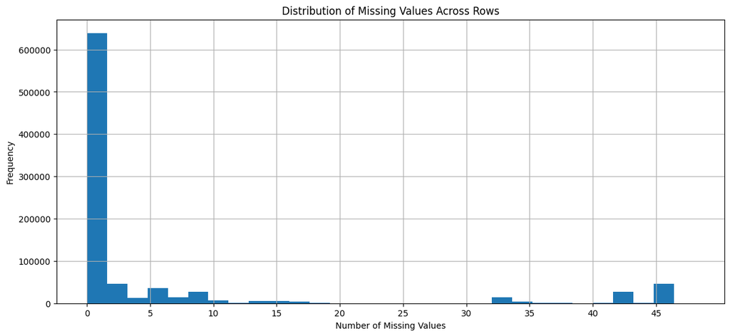

```python
# Plot the histogram of missing value counts
plt.figure(figsize=(14, 6))
row_na_counts.hist(bins=30)
plt.title('Distribution of Missing Values Across Rows')
plt.xlabel('Number of Missing Values')
plt.ylabel('Frequency')
plt.xticks(np.arange(0, max(row_na_counts), 5))
plt.show()
```

```python
# Divide the data into two subsets based on the number of missing values in each row.
threshold = 20
azdias_few_na = azdias_cleaned[row_na_counts <= threshold]
azdias_many_na = azdias_cleaned[row_na_counts > threshold]
print(azdias_few_na.shape)
print(azdias_many_na.shape)
```

```
(797442, 78)
(93779, 78)
```

```python
# Randomly choose 5 columns with no missing value
import random
non_null_cols = azdias_cleaned.notnull().all()
cols_to_compare = non_null_cols[non_null_cols==True].sample(5, random_state=7)
# Convert to a list of 5 column names
cols_to_compare = cols_to_compare.index
cols_to_compare.tolist()
```

```
['FINANZ_MINIMALIST',
 'FINANZ_UNAUFFAELLIGER',
 'SEMIO_REL',
 'SEMIO_VERT',
 'FINANZ_SPARER']
```

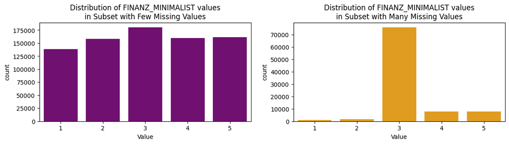

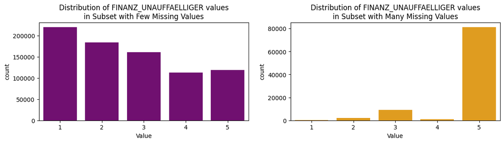

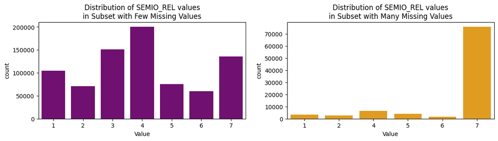

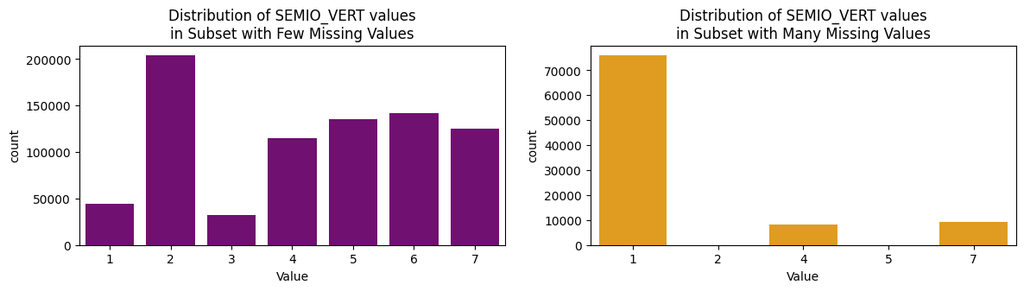

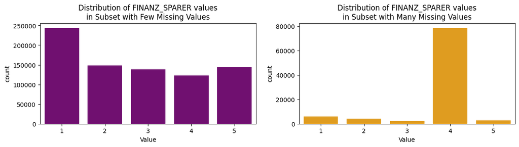

```python
# Compare the distribution of values for at least five columns where there are no or few missing values, between the two subsets.
def compare_distribution(column):
    plt.figure(figsize=(14, 3))

    # Plot for the subset with few missing values
    plt.subplot(1, 2, 1)
    sns.countplot(data=azdias_few_na, x=column, color='purple')
    plt.title(f'Distribution of {column} values\nin Subset with Few Missing Values')
    plt.xlabel('Value')

    # Plot for the subset with many missing values
    plt.subplot(1, 2, 2)
    sns.countplot(data=azdias_many_na, x=column, color='orange')
    plt.title(f'Distribution of {column} values\nin Subset with Many Missing Values')
    plt.xlabel('Value')

    plt.show()

for col in cols_to_compare:
    compare_distribution(col)
```

```python
# Assign the subset of data with fewer missing values to azdias_cleaned
azdias_cleaned = azdias_few_na
```

```python
azdias_cleaned.shape
```

```
(797442, 78)
```

#### Discussion 1.1.3: Assess Missing Data in Each Row

Based on the 'Distribution of Missing Values Across Rows' histogram, most rows have fewer than 20 missing values. Therefore, 20 is the threshold used to divide rows into 2 subsets: rows with few missing values and rows with many missing values.

The subset with many missing values has fewer rows than the subset with few missing values.

The distribution of values in both subsets are different across 5 non-null columns. This suggests that the rows with a higher number of missing values (many_missing) might represent a distinct subset of the data. This could mean that the rows with more missing values have different characteristics compared to those with fewer missing values.

### Step 1.2: Select and Re-Encode Features

Checking for missing data isn't the only way in which we can prepare a dataset for analysis. Since the unsupervised learning techniques to be used will only work on data that is encoded numerically, we need to make a few encoding changes or additional assumptions to be able to make progress. In addition, while almost all of the values in the dataset are encoded using numbers, not all of them represent numeric values. Check the third column of the feature summary (`feat_info`) for a summary of types of measurement.

- For numeric and interval data, these features can be kept without changes.
- Most of the variables in the dataset are ordinal in nature. While ordinal values may technically be non-linear in spacing, make the simplifying assumption that the ordinal variables can be treated as being interval in nature (that is, kept without any changes).
- Special handling may be necessary for the remaining two variable types: categorical, and 'mixed'.

In the first two parts of this sub-step, we will perform an investigation of the categorical and mixed-type features and make a decision on each of them, whether we will keep, drop, or re-encode each. Then, in the last part, we will create a new data frame with only the selected and engineered columns.

Data wrangling is often the trickiest part of the data analysis process, and there's a lot of it to be done here. But stick with it: once we're done with this step, we'll be ready to get to the machine learning parts of the project!

```python
# How many features are there of each data type?
features_cleaned[['attribute','type']]
```

|  | attribute | type |
| --- | --- | --- |
| 0 | AGER_TYP | categorical |
| 1 | ALTERSKATEGORIE_GROB | ordinal |
| 2 | ANREDE_KZ | categorical |
| 3 | CJT_GESAMTTYP | categorical |
| 4 | FINANZ_MINIMALIST | ordinal |
| ... | ... | ... |
| 80 | PLZ8_HHZ | ordinal |
| 81 | PLZ8_GBZ | ordinal |
| 82 | ARBEIT | ordinal |
| 83 | ORTSGR_KLS9 | ordinal |
| 84 | RELAT_AB | ordinal |

85 rows × 2 columns

#### Step 1.2.1: Re-Encode Categorical Features

For categorical data, we would ordinarily need to encode the levels as dummy variables. Depending on the number of categories, we'll perform one of the following:

- For binary (two-level) categoricals that take numeric values, we can keep them without needing to do anything.
- There is one binary variable that takes on non-numeric values. For this one, we need to re-encode the values as numbers or create a dummy variable.
- For multi-level categoricals (three or more values), we can choose to encode the values using multiple dummy variables (e.g. via [OneHotEncoder](http://scikit-learn.org/stable/modules/generated/sklearn.preprocessing.OneHotEncoder.html)), or (to keep things straightforward) just drop them from the analysis.

```python
# Assess categorical variables: which are binary, which are multi-level, and which one needs to be re-encoded?
# Identify categorical columns
categorical_cols = features_cleaned['attribute'][features_cleaned['type'] == 'categorical']
# Check unique values in each categorical column to determine how to handle them
for col in categorical_cols:
    if col in azdias_cleaned.columns: # Make sure to check only features that haven't been removed
        print(f'{col}: {azdias_cleaned[col].unique()}')
```

```
ANREDE_KZ: [2 1]
CJT_GESAMTTYP: [ 5.  3.  2.  4.  1.  6. nan]
FINANZTYP: [1 6 5 2 4 3]
GFK_URLAUBERTYP: [10.  1.  5. 12.  9.  3.  8. 11.  4.  2.  7.  6. nan]
GREEN_AVANTGARDE: [0 1]
LP_FAMILIE_FEIN: [ 5.  1. nan 10.  2.  7. 11.  8.  4.  6.  9.  3.]
LP_FAMILIE_GROB: [ 3.  1. nan  5.  2.  4.]
LP_STATUS_FEIN: [ 2.  3.  9.  4.  1. 10.  5.  8.  6.  7. nan]
LP_STATUS_GROB: [ 1.  2.  4.  5.  3. nan]
NATIONALITAET_KZ: [ 1.  3.  2. nan]
SHOPPER_TYP: [ 3.  2.  1.  0. nan]
SOHO_KZ: [1. 0.]
VERS_TYP: [ 2.  1. nan]
ZABEOTYP: [5 3 4 1 6 2]
GEBAEUDETYP: [8. 1. 3. 2. 6. 4. 5.]
OST_WEST_KZ: ['W' 'O']
CAMEO_DEUG_2015: [ 8.  4.  2.  6.  1.  9.  5.  7. nan  3.]
```

```python
# Re-encode categorical variable(s) to be kept in the analysis.
azdias_cleaned['OST_WEST_KZ'] = azdias_cleaned['OST_WEST_KZ'].map({'W': 1, 'O': 0}, na_action='ignore')
```

```python
# Check the values in OST_WEST_KZ
azdias_cleaned['OST_WEST_KZ'].unique()
```

```
array([1, 0])
```

```python
# Remove multi-level categorical variables
for col in categorical_cols:
    if col in azdias_cleaned.columns:
        unique_vals = azdias_cleaned[col].dropna().unique() # Get unique non-null values
        # Drop columns that have more than 2 categorical values
        if len(unique_vals) > 2:
            azdias_cleaned.drop(col, axis=1, inplace=True)
            print(f'Dropped {col}')
```

```
Dropped CJT_GESAMTTYP
Dropped FINANZTYP
Dropped GFK_URLAUBERTYP
Dropped LP_FAMILIE_FEIN
Dropped LP_FAMILIE_GROB
Dropped LP_STATUS_FEIN
Dropped LP_STATUS_GROB
Dropped NATIONALITAET_KZ
Dropped SHOPPER_TYP
Dropped ZABEOTYP
Dropped GEBAEUDETYP
Dropped CAMEO_DEUG_2015
```

```python
# Check the number of columns remain
azdias_cleaned.shape[1]
```

```
66
```

#### Discussion 1.2.1: Re-Encode Categorical Features

Binary variables:

- ANREDE_K
- GREEN_AVANTGARDE
- SOHO_KZ
- VERS_TYP
- OST_WEST_KZ

OST_WEST_KZ is a binary variable that takes on non-numeric values (W or O). I re-encoded these values as numbers (1 and 0) using .map() function.

Multi-level categorical features are dropped to simplify the analysis and leave only the binary or non-categorical features (such as ordinal and numeric features).

#### Step 1.2.2: Engineer Mixed-Type Features

There are a handful of features that are marked as "mixed" in the feature summary that require special treatment in order to be included in the analysis. There are two in particular that deserve attention; the handling of the rest are up to our own choices:

- "PRAEGENDE_JUGENDJAHRE" combines information on three dimensions: generation by decade, movement (mainstream vs. avantgarde), and nation (east vs. west). While there aren't enough levels to disentangle east from west, we should create two new variables to capture the other two dimensions: an interval-type variable for decade, and a binary variable for movement.
- "CAMEO_INTL_2015" combines information on two axes: wealth and life stage. Break up the two-digit codes by their 'tens'-place and 'ones'-place digits into two new ordinal variables (which, for the purposes of this project, is equivalent to just treating them as their raw numeric values).

Be sure to check `Data_Dictionary.md` for the details needed to finish these tasks.

**Investigate "PRAEGENDE_JUGENDJAHRE"**

The "PRAEGENDE_JUGENDJAHRE" feature has the following values:

- 1: 40s - war years (Mainstream, E+W)
- 2: 40s - reconstruction years (Avantgarde, E+W)
- 3: 50s - economic miracle (Mainstream, E+W)
- 4: 50s - milk bar / Individualisation (Avantgarde, E+W)
- 5: 60s - economic miracle (Mainstream, E+W)
- 6: 60s - generation 68 / student protestors (Avantgarde, W)
- 7: 60s - opponents to the building of the Wall (Avantgarde, E)
- 8: 70s - family orientation (Mainstream, E+W)
- 9: 70s - peace movement (Avantgarde, E+W)
- 10: 80s - Generation Golf (Mainstream, W)
- 11: 80s - ecological awareness (Avantgarde, W)
- 12: 80s - FDJ / communist party youth organisation (Mainstream, E)
- 13: 80s - Swords into ploughshares (Avantgarde, E)
- 14: 90s - digital media kids (Mainstream, E+W)
- 15: 90s - ecological awareness (Avantgarde, E+W)

```python
# Investigate "PRAEGENDE_JUGENDJAHRE" and engineer two new variables.
# Create dicionaries to map decade variable
decade_mapping = {}
for i in range(1,16):
    if i < 3:
        decade_mapping[i]=40
    elif i < 5:
        decade_mapping[i]=50
    elif i < 8:
        decade_mapping[i]=60
    elif i < 10:
        decade_mapping[i]=70
    elif i < 14:
        decade_mapping[i]=80
    else:
        decade_mapping[i]=90
    print(f'{i}: {decade_mapping[i]}')
```

```
1: 40
2: 40
3: 50
4: 50
5: 60
6: 60
7: 60
8: 70
9: 70
10: 80
11: 80
12: 80
13: 80
14: 90
15: 90
```

```python
# Create dicionaries to map movement variables
movement_mapping = {}
for i in range(1,16):
    if i in [1,3,5,8,10,12,14]:
        movement_mapping[i]=0 # Mainstream
    else:
        movement_mapping[i]=1 # Avantgarde
    print(f'{i}: {movement_mapping[i]}')
```

```
1: 0
2: 1
3: 0
4: 1
5: 0
6: 1
7: 1
8: 0
9: 1
10: 0
11: 1
12: 0
13: 1
14: 0
15: 1
```

```python
# Create new column "PRAEGENDE_JUGENDJAHRE_DECADE"
azdias_cleaned['PRAEGENDE_JUGENDJAHRE_DECADE'] = azdias_cleaned['PRAEGENDE_JUGENDJAHRE'].map(decade_mapping, na_action='ignore')
# Create new column "PRAEGENDE_JUGENDJAHRE_MOVEMENT"
azdias_cleaned['PRAEGENDE_JUGENDJAHRE_MOVEMENT'] = azdias_cleaned['PRAEGENDE_JUGENDJAHRE'].map(movement_mapping, na_action='ignore')

azdias_cleaned[['PRAEGENDE_JUGENDJAHRE','PRAEGENDE_JUGENDJAHRE_DECADE','PRAEGENDE_JUGENDJAHRE_MOVEMENT']].head()
```

|  | PRAEGENDE_JUGENDJAHRE | PRAEGENDE_JUGENDJAHRE_DECADE | PRAEGENDE_JUGENDJAHRE_MOVEMENT |
| --- | --- | --- | --- |
| 1 | 14.0 | 90.0 | 0.0 |
| 2 | 15.0 | 90.0 | 1.0 |
| 3 | 8.0 | 70.0 | 0.0 |
| 4 | 8.0 | 70.0 | 0.0 |
| 5 | 3.0 | 50.0 | 0.0 |

**Investigate "CAMEO_INTL_2015"**

The "CAMEO_INTL_2015" feature has the following values:

- 11: Wealthy Households - Pre-Family Couples & Singles
- 12: Wealthy Households - Young Couples With Children
- 13: Wealthy Households - Families With School Age Children
- 14: Wealthy Households - Older Families & Mature Couples
- 15: Wealthy Households - Elders In Retirement
- 21: Prosperous Households - Pre-Family Couples & Singles
- 22: Prosperous Households - Young Couples With Children
- 23: Prosperous Households - Families With School Age Children
- 24: Prosperous Households - Older Families & Mature Couples
- 25: Prosperous Households - Elders In Retirement
- 31: Comfortable Households - Pre-Family Couples & Singles
- 32: Comfortable Households - Young Couples With Children
- 33: Comfortable Households - Families With School Age Children
- 34: Comfortable Households - Older Families & Mature Couples
- 35: Comfortable Households - Elders In Retirement
- 41: Less Affluent Households - Pre-Family Couples & Singles
- 42: Less Affluent Households - Young Couples With Children
- 43: Less Affluent Households - Families With School Age Children
- 44: Less Affluent Households - Older Families & Mature Couples
- 45: Less Affluent Households - Elders In Retirement
- 51: Poorer Households - Pre-Family Couples & Singles
- 52: Poorer Households - Young Couples With Children
- 53: Poorer Households - Families With School Age Children
- 54: Poorer Households - Older Families & Mature Couples
- 55: Poorer Households - Elders In Retirement

```python
# Investigate CAMEO_INTL_2015 and engineer two new variables
azdias_cleaned['CAMEO_WEALTH'] = azdias_cleaned['CAMEO_INTL_2015'].apply(lambda x: x//10)
azdias_cleaned['CAMEO_LIFE_STAGE'] = azdias_cleaned['CAMEO_INTL_2015'].apply(lambda x: x%10)
azdias_cleaned[['CAMEO_INTL_2015', 'CAMEO_WEALTH', 'CAMEO_LIFE_STAGE']].head()
```

|  | CAMEO_INTL_2015 | CAMEO_WEALTH | CAMEO_LIFE_STAGE |
| --- | --- | --- | --- |
| 1 | 51.0 | 5.0 | 1.0 |
| 2 | 24.0 | 2.0 | 4.0 |
| 3 | 12.0 | 1.0 | 2.0 |
| 4 | 43.0 | 4.0 | 3.0 |
| 5 | 54.0 | 5.0 | 4.0 |

```python
# Number of columns after adding 4 new variables
azdias_cleaned.shape[1]
```

```
70
```

```python
# Identify other mixed-type features
mixed_cols = features_cleaned['attribute'][features_cleaned['type'] == 'mixed']
mixed_cols[(mixed_cols.isin(azdias_cleaned.columns)) & (mixed_cols != 'PRAEGENDE_JUGENDJAHRE') & (mixed_cols != 'CAMEO_INTL_2015')]
```

```
15    LP_LEBENSPHASE_FEIN
16    LP_LEBENSPHASE_GROB
56               WOHNLAGE
79            PLZ8_BAUMAX
Name: attribute, dtype: object
```

```python
# Drop 3 mix-typed columns 'LP_LEBENSPHASE_FEIN', 'LP_LEBENSPHASE_GROB', and 'PLZ8_BAUMAX'
azdias_cleaned.drop(['LP_LEBENSPHASE_FEIN', 'LP_LEBENSPHASE_GROB', 'PLZ8_BAUMAX'], axis=1, inplace=True)
```

```python
# Number of columns remain after dropping some columns
azdias_cleaned.shape[1]
```

```
67
```

#### Discussion 1.2.2: Engineer Mixed-Type Features

Engineering steps:

- Split PRAEGENDE_JUGENDJAHRE into Decade and Movement.
- Split CAMEO_INTL_2015 into CAMEO_WEALTH and CAMEO_LIFE_STAGE.

According to the information in Data_Dictionary.md about other mixed-type features, values in 'LP_LEBENSPHASE_FEIN' and 'LP_LEBENSPHASE_GROB' represent life stages. Since I already have 'CAMEO_WEALTH' and 'CAMEO_LIFE_STAGE', which provide similar information, we can drop these features.

'PLZ8_BAUMAX' (Most common building type within the PLZ8 region) doesn't seem to add significant predictive power for identifying likely purchasers in a mailout campaign. I've decided to drop it.

'WOHNLAGE' is retained as it might provide valuable neighborhood-related insights.

#### Step 1.2.3: Complete Feature Selection

In order to finish this step up, we need to make sure that our data frame now only has the columns that we want to keep. To summarize, the dataframe should consist of the following:

- All numeric, interval, and ordinal type columns from the original dataset.
- Binary categorical features (all numerically-encoded).
- Engineered features from other multi-level categorical features and mixed features.

```python
# Take care of other re-engineering tasks
azdias_cleaned.drop(['PRAEGENDE_JUGENDJAHRE', 'CAMEO_INTL_2015'], axis=1, inplace=True)
```

```python
azdias_cleaned.shape
```

```
(797442, 65)
```

```python
# Check for the binary columns in the dataset
for col in azdias_cleaned.columns:
    unique_vals = azdias_cleaned[col].dropna().unique() # Get unique non-null values
    if len(unique_vals) == 2:
        print(col)
```

```
ANREDE_KZ
GREEN_AVANTGARDE
SOHO_KZ
VERS_TYP
OST_WEST_KZ
PRAEGENDE_JUGENDJAHRE_MOVEMENT
```

```python
# Check for feature type of columns from the original dataset and engineered features
for col in azdias_cleaned.columns:
    result = features_cleaned.query('attribute == @col')['type'].values
    print(f'{col}: {result}')
```

```
ALTERSKATEGORIE_GROB: ['ordinal']
ANREDE_KZ: ['categorical']
FINANZ_MINIMALIST: ['ordinal']
FINANZ_SPARER: ['ordinal']
FINANZ_VORSORGER: ['ordinal']
FINANZ_ANLEGER: ['ordinal']
FINANZ_UNAUFFAELLIGER: ['ordinal']
FINANZ_HAUSBAUER: ['ordinal']
GREEN_AVANTGARDE: ['categorical']
HEALTH_TYP: ['ordinal']
RETOURTYP_BK_S: ['ordinal']
SEMIO_SOZ: ['ordinal']
SEMIO_FAM: ['ordinal']
SEMIO_REL: ['ordinal']
SEMIO_MAT: ['ordinal']
SEMIO_VERT: ['ordinal']
SEMIO_LUST: ['ordinal']
SEMIO_ERL: ['ordinal']
SEMIO_KULT: ['ordinal']
SEMIO_RAT: ['ordinal']
SEMIO_KRIT: ['ordinal']
SEMIO_DOM: ['ordinal']
SEMIO_KAEM: ['ordinal']
SEMIO_PFLICHT: ['ordinal']
SEMIO_TRADV: ['ordinal']
SOHO_KZ: ['categorical']
VERS_TYP: ['categorical']
ANZ_PERSONEN: ['numeric']
ANZ_TITEL: ['numeric']
HH_EINKOMMEN_SCORE: ['ordinal']
W_KEIT_KIND_HH: ['ordinal']
WOHNDAUER_2008: ['ordinal']
ANZ_HAUSHALTE_AKTIV: ['numeric']
ANZ_HH_TITEL: ['numeric']
KONSUMNAEHE: ['ordinal']
MIN_GEBAEUDEJAHR: ['numeric']
OST_WEST_KZ: ['categorical']
WOHNLAGE: ['mixed']
KBA05_ANTG1: ['ordinal']
KBA05_ANTG2: ['ordinal']
```

[output cut: 10 more lines]

```
REGIOTYP: ['ordinal']
KBA13_ANZAHL_PKW: ['numeric']
PLZ8_ANTG1: ['ordinal']
PLZ8_ANTG2: ['ordinal']
PLZ8_ANTG3: ['ordinal']
PLZ8_ANTG4: ['ordinal']
PLZ8_HHZ: ['ordinal']
PLZ8_GBZ: ['ordinal']
ARBEIT: ['ordinal']
ORTSGR_KLS9: ['ordinal']
RELAT_AB: ['ordinal']
PRAEGENDE_JUGENDJAHRE_DECADE: []
PRAEGENDE_JUGENDJAHRE_MOVEMENT: []
CAMEO_WEALTH: []
CAMEO_LIFE_STAGE: []
```

### Step 1.3: Create a Cleaning Function

Even though we've finished cleaning up the general population demographics data, it's important to look ahead to the future and realize that we'll need to perform the same cleaning steps on the customer demographics data. In this substep, we'll complete the function below to execute the main feature selection, encoding, and re-engineering steps we performed above. Then, when it comes to looking at the customer data in Step 3, we can just run this function on that DataFrame to get the trimmed dataset in a single step.

```python
def clean_data(df, feat_info):
    """
    Perform feature trimming, re-encoding, and engineering for demographics
    data

    INPUT: Demographics DataFrame and Feature Summary DataFrame
    OUTPUT: Trimmed and cleaned demographics DataFrame
    """
    # CONVERTING MISSING VALUE CODES TO NaN

    # Create copies of the raw datasets
    features_cleaned = feat_info.copy()
    df_cleaned = df.copy()

    # Parsing the string values to lists and convert numeric strings to integers
    features_cleaned['missing_or_unknown'] = features_cleaned['missing_or_unknown'].apply(lambda x: x.strip('[]').split(','))
    features_cleaned['missing_or_unknown'] = features_cleaned['missing_or_unknown'].apply(lambda x: [int(code) if code.lstrip('-').isdigit() else code for code in x])
    # Convert data that matches a 'missing' or 'unknown' value code into a numpy NaN value
    for row in range(len(features_cleaned)):
        column = features_cleaned.loc[row,'attribute']  # Column name
        missing_codes = features_cleaned.loc[row,'missing_or_unknown']  # List of missing codes
        # Convert those specific values to NaN in the 'azdias_cleaned' dataframe
        if missing_codes:  # Only apply if there are missing codes
            for code in missing_codes:
                df_cleaned[column] = df_cleaned[column].replace(code, np.nan)

    # Convert object type columns that have valid numeric values and 'X' or 'XX' as missing values to a numeric type
    # Identify columns names
    x_cols = df.columns[azdias.isin(['X','XX']).any()]
    # Convert columns that have valid numeric values
    for col in x_cols:
        df_cleaned[col] = pd.to_numeric(df_cleaned[col], errors='coerce')


    # REMOVE COLUMNS

    # Remove columns with many missing values
    outlier_cols = ['AGER_TYP', 'GEBURTSJAHR', 'TITEL_KZ', 'ALTER_HH', 'KK_KUNDENTYP', 'KBA05_BAUMAX']
    df_cleaned.drop(outlier_cols, axis=1, inplace=True)

    # Remove multi-level categorical variables
    multi_lv_cols = ['CJT_GESAMTTYP', 'FINANZTYP', 'GFK_URLAUBERTYP', 'LP_FAMILIE_FEIN', 'LP_FAMILIE_GROB', 'LP_STATUS_FEIN',
                    'LP_STATUS_GROB', 'NATIONALITAET_KZ', 'SHOPPER_TYP', 'ZABEOTYP', 'GEBAEUDETYP', 'CAMEO_DEUG_2015', 'CAMEO_DEU_2015']
    df_cleaned.drop(multi_lv_cols, axis=1, inplace=True)

    # Drop 3 mix-typed columns 'LP_LEBENSPHASE_FEIN', 'LP_LEBENSPHASE_GROB', and 'PLZ8_BAUMAX'
    df_cleaned.drop(['LP_LEBENSPHASE_FEIN', 'LP_LEBENSPHASE_GROB', 'PLZ8_BAUMAX'], axis=1, inplace=True)


    # REMOVE ROWS

    # Remove the subset of data with more than 30 missing values per row
    threshold = 20
    df_cleaned = df_cleaned[df_cleaned.isna().sum(axis=1) <= threshold]


    # ENGINEER COLUMN VALUES

    # Re-encode binary column 'OST_WEST_KZ'
    df_cleaned['OST_WEST_KZ'] = df_cleaned['OST_WEST_KZ'].map({'W': 1, 'O': 0}, na_action='ignore')

    # Engineer two new variables from "PRAEGENDE_JUGENDJAHRE"
    # Create dicionaries to map decade variable
    decade_mapping = {}
    for i in range(1,16):
        if i < 3:
            decade_mapping[i]=40
        elif i < 5:
            decade_mapping[i]=50
        elif i < 8:
            decade_mapping[i]=60
        elif i < 10:
            decade_mapping[i]=70
        elif i < 14:
            decade_mapping[i]=80
        else:
            decade_mapping[i]=90

    # Create dicionaries to map movement variables
    movement_mapping = {}
    for i in range(1,16):
        if i in [1,3,5,8,10,12,14]:
            movement_mapping[i]=0 # Mainstream
        else:
            movement_mapping[i]=1 # Avantgarde

    # Create new column "PRAEGENDE_JUGENDJAHRE_DECADE"
    df_cleaned['PRAEGENDE_JUGENDJAHRE_DECADE'] = df_cleaned['PRAEGENDE_JUGENDJAHRE'].map(decade_mapping, na_action='ignore')
    # Create new column "PRAEGENDE_JUGENDJAHRE_MOVEMENT"
    df_cleaned['PRAEGENDE_JUGENDJAHRE_MOVEMENT'] = df_cleaned['PRAEGENDE_JUGENDJAHRE'].map(movement_mapping, na_action='ignore')

    # Engineer two new variables from "CAMEO_INTL_2015"
    df_cleaned['CAMEO_WEALTH'] = df_cleaned['CAMEO_INTL_2015'].apply(lambda x: x//10)
    df_cleaned['CAMEO_LIFE_STAGE'] = df_cleaned['CAMEO_INTL_2015'].apply(lambda x: x%10)

    # Drop "PRAEGENDE_JUGENDJAHRE" and "CAMEO_INTL_2015"
    df_cleaned.drop(['PRAEGENDE_JUGENDJAHRE', 'CAMEO_INTL_2015'], axis=1, inplace=True)

    # Return the cleaned dataframe.
    return df_cleaned
```

## Step 2: Feature Transformation

### Step 2.1: Apply Feature Scaling

Before we apply dimensionality reduction techniques to the data, we need to perform feature scaling so that the principal component vectors are not influenced by the natural differences in scale for features. Starting from this part of the project, we'll want to keep an eye on the [API reference page for sklearn](http://scikit-learn.org/stable/modules/classes.html) to help navigate to all of the classes and functions that we'll need. In this substep, we'll need to check the following:

- sklearn requires that data not have missing values in order for its estimators to work properly. So, before applying the scaler to the data, make sure that we've cleaned the DataFrame of the remaining missing values. This can be as simple as just removing all data points with missing data, or applying an [Imputer](https://scikit-learn.org/0.16/modules/generated/sklearn.preprocessing.Imputer.html) to replace all missing values. We might also try a more complicated procedure where we temporarily remove missing values in order to compute the scaling parameters before re-introducing those missing values and applying imputation.
- For the actual scaling function, a [StandardScaler](http://scikit-learn.org/stable/modules/generated/sklearn.preprocessing.StandardScaler.html) instance is suggested, scaling each feature to mean 0 and standard deviation 1.
- For these classes, we can make use of the `.fit_transform()` method to both fit a procedure to the data as well as apply the transformation to the data at the same time.

```python
from sklearn.preprocessing import StandardScaler
from sklearn.impute import SimpleImputer
```

```python
azdias_cleaned.shape
```

```
(797442, 65)
```

```python
# Check columns with missing values
na_counts = azdias_cleaned.isna().sum().sort_values(ascending=False)
na_counts = na_counts[na_counts>0]
na_counts
```

```
REGIOTYP              64442
KKK                   64442
W_KEIT_KIND_HH        58905
KBA05_ANTG3           39547
KBA05_ANTG4           39547
                      ...
EWDICHTE                591
INNENSTADT              591
BALLRAUM                591
KONSUMNAEHE              70
GEBAEUDETYP_RASTER        7
Length: 35, dtype: int64
```

```python
# Checking the proportions of missing values in each column
missing_proportion = azdias_cleaned.isna().mean()
missing_proportion[missing_proportion>0].sort_values(ascending=False)
```

```
KKK                   0.080811
REGIOTYP              0.080811
W_KEIT_KIND_HH        0.073867
KBA05_ANTG1           0.049592
MOBI_REGIO            0.049592
                        ...
EWDICHTE              0.000741
BALLRAUM              0.000741
INNENSTADT            0.000741
KONSUMNAEHE           0.000088
GEBAEUDETYP_RASTER    0.000009
Length: 35, dtype: float64
```

The proportions of missing values for each column are fairly small. These columns likely have sufficient information in the remaining non-null values to justify imputation, rather than removing them.

```python
# Inspect feature types of columns that have missing values
for col in na_counts.index:
    result = features_cleaned.query('attribute == @col')['type'].values
    print(f'{col}: {result}')
```

```
REGIOTYP: ['ordinal']
KKK: ['ordinal']
W_KEIT_KIND_HH: ['ordinal']
KBA05_ANTG3: ['ordinal']
KBA05_ANTG4: ['ordinal']
KBA05_ANTG2: ['ordinal']
KBA05_ANTG1: ['ordinal']
MOBI_REGIO: ['ordinal']
KBA05_GBZ: ['ordinal']
VERS_TYP: ['categorical']
HEALTH_TYP: ['ordinal']
PRAEGENDE_JUGENDJAHRE_DECADE: []
PRAEGENDE_JUGENDJAHRE_MOVEMENT: []
PLZ8_GBZ: ['ordinal']
PLZ8_ANTG2: ['ordinal']
PLZ8_ANTG4: ['ordinal']
PLZ8_ANTG1: ['ordinal']
PLZ8_ANTG3: ['ordinal']
PLZ8_HHZ: ['ordinal']
KBA13_ANZAHL_PKW: ['numeric']
ANZ_HAUSHALTE_AKTIV: ['numeric']
CAMEO_WEALTH: []
CAMEO_LIFE_STAGE: []
ONLINE_AFFINITAET: ['ordinal']
RETOURTYP_BK_S: ['ordinal']
ARBEIT: ['ordinal']
RELAT_AB: ['ordinal']
ORTSGR_KLS9: ['ordinal']
ANZ_HH_TITEL: ['numeric']
ALTERSKATEGORIE_GROB: ['ordinal']
EWDICHTE: ['ordinal']
INNENSTADT: ['ordinal']
BALLRAUM: ['ordinal']
KONSUMNAEHE: ['ordinal']
GEBAEUDETYP_RASTER: ['ordinal']
```

I will apply different imputing strategies to different feature types.

```python
# Create a function to impute missing values
def impute_na (df, feat):

    # Using SimpleImputer to impute missing values
    med_imputer = SimpleImputer(strategy='median')
    mode_imputer = SimpleImputer(strategy='most_frequent')

    # Impute numeric columns
    numeric_cols = feat['attribute'][feat['type'] == 'numeric'].tolist()   # Create a list of column names for numeric columns
    for col in numeric_cols:
        if col in df.columns.tolist():  # Make sure the column exists in the customer data
            df[col] = med_imputer.fit_transform(df[[col]])

    # Impute binary columns
    binary_cols = []
    for col in df.columns:
        unique_vals = df[col].dropna().unique()  # Get unique non-null values
        if len(unique_vals) == 2:  # Check if there are exactly two unique values (binary)
            binary_cols.append(col)   # Create a list of column names for binary columns
    df[binary_cols] = mode_imputer.fit_transform(df[binary_cols])

    # Impute ordinal columns
    ord_cols = feat['attribute'][feat['type'] == 'ordinal'].tolist()   # Create a list of column names for ordinal columns
    ord_cols += ['CAMEO_LIFE_STAGE', 'CAMEO_WEALTH']   # Add 2 engineered columns
    for col in ord_cols:
        if col in df.columns.tolist():   # Make sure the column exists in the customer data
            df[col] = mode_imputer.fit_transform(df[[col]])

    # Impute missing values in interval column 'PRAEGENDE_JUGENDJAHRE_DECADE'
    df['PRAEGENDE_JUGENDJAHRE_DECADE'] = med_imputer.fit_transform(df[['PRAEGENDE_JUGENDJAHRE_DECADE']])
```

```python
# Call impute_na function to handle missing values
impute_na(azdias_cleaned, features)
```

```python
# Check for missing values again
na_counts = azdias_cleaned.isna().sum()
na_counts = na_counts[na_counts>0]
na_counts
```

```
Series([], dtype: int64)
```

```python
# Apply feature scaling to the general population demographics data.
scaled_data = StandardScaler().fit_transform(azdias_cleaned)
azdias_scaled = pd.DataFrame(scaled_data, columns=azdias_cleaned.columns)
```

```python
azdias_scaled.shape
```

```
(797442, 65)
```

### Discussion 2.1: Apply Feature Scaling

- I applied median imputation for numeric columns because the median provides a robust central value that is less influenced by outliers and is representative of the data distribution, especially for skewed or continuous data.
- For binary columns, I used the mode to ensure consistency with the majority class and the simplicity of the binary feature.
- I used the mode for ordinal columns as it respects the categorical nature of the data while maintaining the overall distribution.
- The median was used to impute NaN values in the interval column because median preserves central tendency and is resistant to outliers

I scaled the data using the StandardScaler from sklearn to ensure all features are on the same scale (mean = 0, standard deviation = 1).

### Step 2.2: Perform Dimensionality Reduction

On our scaled data, we are now ready to apply dimensionality reduction techniques.

- Use sklearn's [PCA](http://scikit-learn.org/stable/modules/generated/sklearn.decomposition.PCA.html) class to apply principal component analysis on the data, thus finding the vectors of maximal variance in the data. To start, we should not set any parameters (so all components are computed) or set a number of components that is at least half the number of features (so there's enough features to see the general trend in variability).
- Check out the ratio of variance explained by each principal component as well as the cumulative variance explained. Try plotting the cumulative or sequential values using matplotlib's [`plot()`](https://matplotlib.org/api/_as_gen/matplotlib.pyplot.plot.html) function. Based on what we find, we can select a value for the number of transformed features we'll retain for the clustering part of the project.
- Once we've made a choice for the number of components to keep, we re-fit a PCA instance to perform the decided-on transformation.

```python
# Apply PCA to the data.
from sklearn.decomposition import PCA
pca = PCA()
pca.fit(azdias_scaled)
```

```
PCA()
```

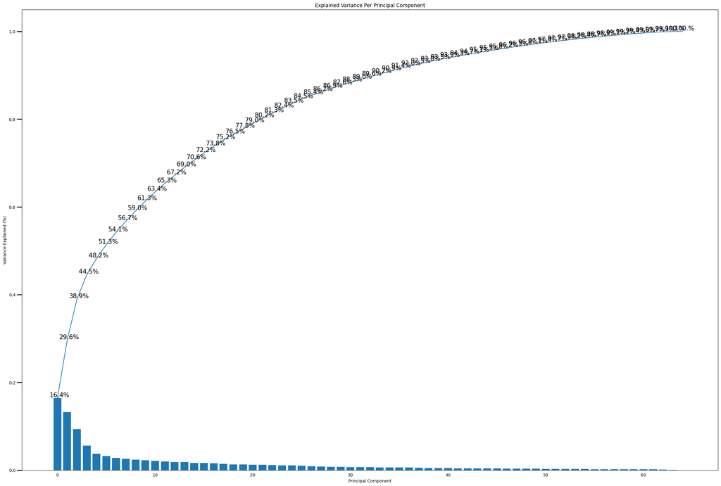

```python
# Investigate the variance accounted for by each principal component.
# Creates a scree plot associated with the principal components
num_components = len(pca.explained_variance_ratio_)
components = np.arange(num_components)
explained_variance = pca.explained_variance_ratio_
cum_explained_variance = np.cumsum(explained_variance)

plt.figure(figsize=(30, 20))
ax = plt.subplot(111)
ax.bar(components, explained_variance)
ax.plot(components, cum_explained_variance)
for i in range(num_components):
    ax.annotate(r"%s%%" % ((str(cum_explained_variance[i]*100)[:4])), (components[i]+0.2, cum_explained_variance[i]), va="bottom", ha="center", fontsize=15)

ax.xaxis.set_tick_params(width=0)
ax.yaxis.set_tick_params(width=2, length=12)

ax.set_xlabel("Principal Component")
ax.set_ylabel("Variance Explained (%)")
plt.title('Explained Variance Per Principal Component')
```

```python
# Further examine the cummulative explained variance
cum_explained_variance = pd.Series(cum_explained_variance, index=range(1, len(cum_explained_variance) + 1))
cum_explained_variance = cum_explained_variance*100
```

```python
cum_explained_variance[cum_explained_variance < 91]
```

```
1     16.409082
2     29.629970
3     38.953836
4     44.523826
5     48.235750
        ...
31    88.370447
32    89.031103
33    89.671508
34    90.292219
35    90.906284
Length: 35, dtype: float64
```

```python
# Re-apply PCA to the data while selecting for number of components to retain.
pca = PCA(n_components=34)
pca_data = pca.fit_transform(azdias_scaled)

pca_data.shape
```

```
(797442, 34)
```

### Step 2.3: Interpret Principal Components

Now that we have our transformed principal components, it's a nice idea to check out the weight of each variable on the first few components to see if they can be interpreted in some fashion.

As a reminder, each principal component is a unit vector that points in the direction of highest variance (after accounting for the variance captured by earlier principal components). The further a weight is from zero, the more the principal component is in the direction of the corresponding feature. If two features have large weights of the same sign (both positive or both negative), then increases in one tend expect to be associated with increases in the other. To contrast, features with different signs can be expected to show a negative correlation: increases in one variable should result in a decrease in the other.

- To investigate the features, we should map each weight to their corresponding feature name, then sort the features according to weight. The most interesting features for each principal component, then, will be those at the beginning and end of the sorted list. We can use the data dictionary document to help us understand these most prominent features, their relationships, and what a positive or negative value on the principal component might indicate.
- We should investigate and interpret feature associations from the first three principal components in this substep. To help facilitate this, we should write a function that we can call at any time to print the sorted list of feature weights, for the *i*-th principal component. This might come in handy in the next step of the project, when we interpret the tendencies of the discovered clusters.

```python
# Map weights for the first principal component to corresponding feature names and then print the linked values, sorted by weight.
def print_pca_weights(pca, feature_names, ith_component):
    # Get the components (weights) of the PCA model
    components = pca.components_
    pc_weights = pd.DataFrame({
            'Feature': feature_names,
            'Weight': components[ith_component]
    })
    pc_weights_sorted = pc_weights.sort_values(by='Weight', ascending=False)
    print(pc_weights_sorted)

print_pca_weights(pca, list(azdias_scaled.columns), 0)
```

```
               Feature    Weight
54          PLZ8_ANTG3  0.227651
55          PLZ8_ANTG4  0.218323
63        CAMEO_WEALTH  0.204273
59         ORTSGR_KLS9  0.202195
29  HH_EINKOMMEN_SCORE  0.200328
..                 ...       ...
38         KBA05_ANTG1 -0.214287
42           KBA05_GBZ -0.216629
2    FINANZ_MINIMALIST -0.219555
48          MOBI_REGIO -0.225258
52          PLZ8_ANTG1 -0.226782

[65 rows x 2 columns]
```

```python
# Map weights for the second principal component to corresponding feature names and then print the linked values, sorted by weight.
print_pca_weights(pca, list(azdias_scaled.columns), 1)
```

```
                         Feature    Weight
0           ALTERSKATEGORIE_GROB  0.258985
4               FINANZ_VORSORGER  0.231989
17                     SEMIO_ERL  0.230291
16                    SEMIO_LUST  0.182736
10                RETOURTYP_BK_S  0.163139
..                           ...       ...
23                 SEMIO_PFLICHT -0.226851
24                   SEMIO_TRADV -0.230324
3                  FINANZ_SPARER -0.234608
61  PRAEGENDE_JUGENDJAHRE_DECADE -0.250858
13                     SEMIO_REL -0.254044

[65 rows x 2 columns]
```

```python
# Map weights for the third principal component to corresponding feature names and then print the linked values, sorted by weight.
print_pca_weights(pca, list(azdias_scaled.columns), 2)
```

```
              Feature    Weight
1           ANREDE_KZ  0.367835
22         SEMIO_KAEM  0.335609
21          SEMIO_DOM  0.312821
20         SEMIO_KRIT  0.275674
19          SEMIO_RAT  0.217448
..                ...       ...
2   FINANZ_MINIMALIST -0.155861
18         SEMIO_KULT -0.234321
12          SEMIO_FAM -0.249512
11          SEMIO_SOZ -0.261952
15         SEMIO_VERT -0.345204

[65 rows x 2 columns]
```

### Discussion 2.3: Interpret Principal Components

**The first principal component:**

- Features like PLZ8_ANTG3, PLZ8_ANTG4, CAMEO_WEALTH, ORTSGR_KLS9 and HH_EINKOMMEN_SCORE have high positive weights, which suggests that these features are highly correlated with the first principal component. These features seem to capture socio-economic factors, such as wealth, income and residential areas.
- Negative features like MOBI_REGIO, KONSUMNAEHE, INNENSTADT and KBA05_ANTG1 capture movement pattern, consumption proximity, city-centered factors. This component is inversely related to minimalist financial behavior, low mobility, and certain postal code areas. This component seems to distinguish between wealthier, more mobile, and higher-income groups vs. individuals with more minimalist financial behavior and lower mobility. Essentially, lower values in urban proximity and higher values in housing density tend to be associated with high values in the socio-economic features like wealth and income.

**The second principal component:**

- There are positively correlated features like ALTERSKATEGORIE_GROB, FINANZ_VORSORGER (financial planning tendency), and SEMIO_ERL (event oriented) which are related to age, financial habits, and lifestyle.
- Features like SEMIO_TRADV, FINANZ_SPARER, PRAEGENDE_JUGENDJAHRE_DECADE, and SEMIO_REL show negative weights. These are also features related to financial status, lifestyle and age. This component seems to be capturing the contrast between younger and older generations and their differing financial behaviors. Older generations with strong sense of reposibility tend to be more conservative, more focused on financial planning and saving.

**The third principlal component:**

- SEMIO_VERT (environmentally-minded), SEMIO_SOZ (socially-minded), and SEMIO_FAM (family-minded) all have large negative weights, which might indicate that this component captures lifestyle and value orientations. These features tend to correlate with individuals who are more concerned about societal or family aspects of life.
- The top features suggest a contrast, with positive values associated with less social engagement or responsibility. SEMIO_DOM (domesticity) and SEMIO_KAEM (family or domestic-oriented behavior) correlate positively with social or family values. ANREDE_KZ (salutation type) with a positive correlation could indicate that more formal, distant, or impersonal interactions are associated with this component’s positive values.

This component reflects a distinction between individuals with strong social, family, and cultural values (negative weights) versus those with more formal, impersonal behaviors (positive weights).

## Step 3: Clustering

### Step 3.1: Apply Clustering to General Population

We've assessed and cleaned the demographics data, then scaled and transformed them. Now, it's time to see how the data clusters in the principal components space. In this substep, we will apply k-means clustering to the dataset and use the average within-cluster distances from each point to their assigned cluster's centroid to decide on a number of clusters to keep.

- Use sklearn's KMeans class to perform k-means clustering on the PCA-transformed data.
- Then, compute the average difference from each point to its assigned cluster's center. **Hint**: The KMeans object's `.score()` method might be useful here, but note that in sklearn, scores tend to be defined so that larger is better. Try applying it to a small, toy dataset, or use an internet search to help understanding.
- Perform the above two steps for a number of different cluster counts. We can then see how the average distance decreases with an increasing number of clusters. However, each additional cluster provides a smaller net benefit. Use this fact to select a final number of clusters in which to group the data. **Warning**: because of the large size of the dataset, it can take a long time for the algorithm to resolve. The more clusters to fit, the longer the algorithm will take. We should test for cluster counts through at least 10 clusters to get the full picture, but we shouldn't need to test for a number of clusters above about 30.
- Once we've selected a final number of clusters to use, re-fit a KMeans instance to perform the clustering operation. Make sure that we also obtain the cluster assignments for the general demographics data, since we'll be using them in the final Step 3.3.

```python
from sklearn.cluster import KMeans

scores = []
# Over a number of different cluster counts...
for k in range (1,11):

    # run k-means clustering on the data and...
    kmeans = KMeans(n_clusters=k, random_state=42)
    # fit the model to data
    model = kmeans.fit(pca_data)
    # compute the average within-cluster distances.
    scores.append(abs(model.score(pca_data)))

centers = list(range(1,11))
```

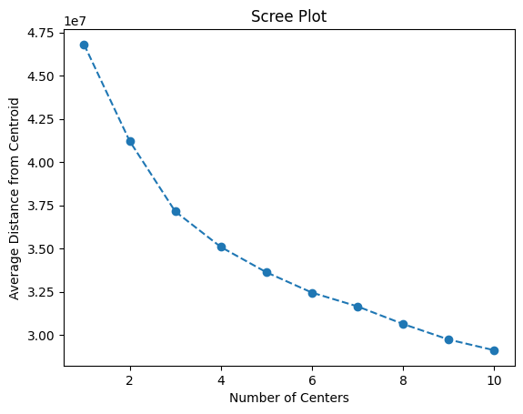

```python
# Investigate the change in within-cluster distance across number of clusters.
plt.plot(centers, scores, marker='o', linestyle='--')
plt.title('Scree Plot')
plt.xlabel('Number of Centers')
plt.ylabel('Average Distance from Centroid')
plt.show()
```

```python
# Re-fit the k-means model with the selected number of clusters and obtain cluster predictions for the general population demographics data.
final_kmeans = KMeans(n_clusters=4, random_state = 42)
final_kmeans.fit(pca_data)
cluster_assignments = final_kmeans.labels_
```

```python
# Add the cluster labels to the demographics dataframe
azdias_cleaned['Cluster'] = cluster_assignments
```

### Discussion 3.1: Apply Clustering to General Population

After applying the k-means clustering algorithm, I used the elbow method to determine the optimal number of clusters. By plotting the average within-cluster distance for different cluster counts, I observed that the decrease in distance slowed down after 4 clusters. This suggested that 4 clusters would capture the most meaningful segmentation with diminishing returns for additional clusters. Thus, I decided to segment the population into 4 clusters.

### Step 3.2: Apply All Steps to the Customer Data

Now that we have clusters and cluster centers for the general population, it's time to see how the customer data maps on to those clusters. Take care to not confuse this for re-fitting all of the models to the customer data. Instead, we're going to use the fits from the general population to clean, transform, and cluster the customer data. In the last step of the project, we will interpret how the general population fits apply to the customer data.

- Don't forget when loading in the customers data, that it is semicolon (`;`) delimited.
- Apply the same feature wrangling, selection, and engineering steps to the customer demographics using the `clean_data()` function we created earlier. (We can assume that the customer demographics data has similar meaning behind missing data patterns as the general demographics data.)
- Use the sklearn objects from the general demographics data, and apply their transformations to the customers data. That is, we should not be using a `.fit()` or `.fit_transform()` method to re-fit the old objects, nor should we be creating new sklearn objects! Carry the data through the feature scaling, PCA, and clustering steps, obtaining cluster assignments for all of the data in the customer demographics data.

```python
# Load in the customer demographics data.
customers = pd.read_csv('Udacity_CUSTOMERS_Subset.csv', sep=';')
```

```python
customers.shape
```

```
(191652, 85)
```

```python
# Apply data processing
customers_cleaned = clean_data(customers, features)
customers_cleaned.head(1)
```

|  | ALTERSKATEGORIE_GROB | ANREDE_KZ | FINANZ_MINIMALIST | FINANZ_SPARER | FINANZ_VORSORGER | FINANZ_ANLEGER | FINANZ_UNAUFFAELLIGER | FINANZ_HAUSBAUER | GREEN_AVANTGARDE | HEALTH_TYP | RETOURTYP_BK_S | SEMIO_SOZ | SEMIO_FAM | SEMIO_REL | SEMIO_MAT | SEMIO_VERT | SEMIO_LUST | SEMIO_ERL | SEMIO_KULT | SEMIO_RAT | SEMIO_KRIT | SEMIO_DOM | SEMIO_KAEM | SEMIO_PFLICHT | SEMIO_TRADV | SOHO_KZ | VERS_TYP | ANZ_PERSONEN | ANZ_TITEL | … |
| --- | --- | --- | --- | --- | --- | --- | --- | --- | --- | --- | --- | --- | --- | --- | --- | --- | --- | --- | --- | --- | --- | --- | --- | --- | --- | --- | --- | --- | --- | --- |
| 0 | 4.0 | 1 | 5 | 1 | 5 | 1 | 2 | 2 | 1 | 1.0 | 5.0 | 6 | 5 | 2 | 6 | 6 | 7 | 3 | 4 | 1 | 3 | 1 | 1 | 2 | 1 | 0.0 | 1.0 | 2.0 | 0.0 | … |

```python
# Check for missing values
na_counts_before = customers_cleaned.isna().sum()
na_counts_before = na_counts[na_counts>0]
na_counts_before
```

```
Series([], dtype: int64)
```

```python
# Handle missing values using impute_na() function
impute_na(customers_cleaned, features)
```

```python
# Check for missing values again
na_counts_after = customers_cleaned.isna().sum()
na_counts_after = na_counts[na_counts>0]
na_counts_after
```

```
Series([], dtype: int64)
```

```python
customers_cleaned.shape
```

```
(141725, 65)
```

```python
# Apply feature scaling
customers_scaled = StandardScaler().fit_transform(customers_cleaned)
```

```python
customers_scaled = pd.DataFrame(customers_scaled, columns=customers_cleaned.columns)
```

```python
# Apply PCA to scaled customer data
customers_pca = pca.transform(customers_scaled)
```

```python
# Use the fitted KMeans model to predict clusters for customer data
customer_cluster_assignments = final_kmeans.predict(customers_pca)
```

```python
# Add the cluster labels to the customer dataframe
customers_cleaned['Cluster'] = customer_cluster_assignments
```

### Step 3.3: Compare Customer Data to Demographics Data

At this point, we have clustered data based on demographics of the general population of Germany, and seen how the customer data for a mail-order sales company maps onto those demographic clusters. In this final substep, we will compare the two cluster distributions to see where the strongest customer base for the company is.

Consider the proportion of persons in each cluster for the general population, and the proportions for the customers. If we think the company's customer base to be universal, then the cluster assignment proportions should be fairly similar between the two. If there are only particular segments of the population that are interested in the company's products, then we should see a mismatch from one to the other. If there is a higher proportion of persons in a cluster for the customer data compared to the general population (e.g. 5% of persons are assigned to a cluster for the general population, but 15% of the customer data is closest to that cluster's centroid) then that suggests the people in that cluster to be a target audience for the company. On the other hand, the proportion of the data in a cluster being larger in the general population than the customer data (e.g. only 2% of customers closest to a population centroid that captures 6% of the data) suggests that group of persons to be outside of the target demographics.

Take a look at the following points in this step:

- Compute the proportion of data points in each cluster for the general population and the customer data. Visualizations will be useful here: both for the individual dataset proportions, but also to visualize the ratios in cluster representation between groups. Seaborn's [`countplot()`](https://seaborn.pydata.org/generated/seaborn.countplot.html) or [`barplot()`](https://seaborn.pydata.org/generated/seaborn.barplot.html) function could be handy.
  - Recall the analysis we performed in step 1.1.3 of the project, where we separated out certain data points from the dataset if they had more than a specified threshold of missing values. If we found that this group was qualitatively different from the main bulk of the data, we should treat this as an additional data cluster in this analysis. Make sure that we account for the number of data points in this subset, for both the general population and customer datasets, when making our computations!
- Which cluster or clusters are overrepresented in the customer dataset compared to the general population? Select at least one such cluster and infer what kind of people might be represented by that cluster. Use the principal component interpretations from step 2.3 or look at additional components to help we make this inference. Alternatively, we can use the `.inverse_transform()` method of the PCA and StandardScaler objects to transform centroids back to the original data space and interpret the retrieved values directly.
- Perform a similar investigation for the underrepresented clusters. Which cluster or clusters are underrepresented in the customer dataset compared to the general population, and what kinds of people are typified by these clusters?

```python
# Total number of data points
total_azdias = azdias.shape[0]
total_customers = customers.shape[0]
```

```python
# The subset of demographics data with many missing values was identified earlier in step 1.1.3
print(f'{azdias_many_na.shape[0]} rows in demographics data have more than 20 missing values.')

# Identify the subset of customer data with many missing values
customers_many_na = customers[customers.isna().sum(axis=1) > 20]
print(f'{customers_many_na.shape[0]} rows in customer data have more than 20 missing values.')
```

```
93779 rows in demographics data have more than 20 missing values.
50033 rows in customer data have more than 20 missing values.
```

```python
# Proportion of rows with missing values in azdias and customers
azdias_missing_proportion = azdias_many_na.shape[0] / total_azdias
customers_missing_proportion = customers_many_na.shape[0] / total_customers
```

```python
# The count of each cluster label in each data
azdias_cluster_counts = azdias_cleaned['Cluster'].value_counts()
customers_cluster_counts = customers_cleaned['Cluster'].value_counts()
```

```python
# Calculate proportions of clusters in each dataset and store them in Series
azdias_cluster_proportions = (azdias_cluster_counts/total_azdias)
customers_cluster_proportions = (customers_cluster_counts/total_customers)
```

```python
# Add proportions of missing values to cluster proportions and assign 'na' as cluster label for missing values
azdias_cluster_proportions.loc['na'] = azdias_missing_proportion
customers_cluster_proportions.loc['na'] = customers_missing_proportion
```

```python
azdias_cluster_proportions
```

```
Cluster
0     0.286119
2     0.236894
1     0.193790
3     0.177972
na    0.105225
Name: count, dtype: float64
```

```python
customers_cluster_proportions
```

```
Cluster
0     0.290516
2     0.199951
1     0.169030
3     0.079994
na    0.261062
Name: count, dtype: float64
```

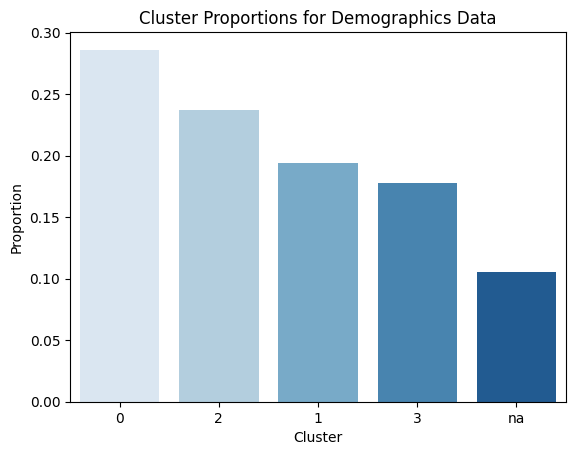

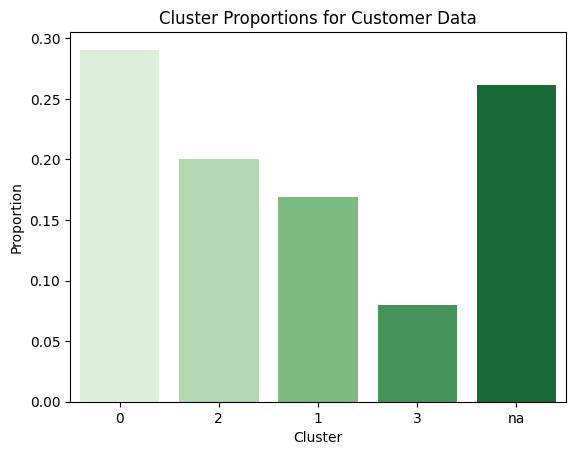

```python
# Visualize proportions for general population
sns.barplot(x=azdias_cluster_proportions.index, y=azdias_cluster_proportions.values, palette='Blues', hue=azdias_cluster_proportions.index, legend=False)
plt.title('Cluster Proportions for Demographics Data')
plt.xlabel('Cluster')
plt.ylabel('Proportion')
plt.show()

# Visualize proportions for customers
sns.barplot(x=customers_cluster_proportions.index, y=customers_cluster_proportions.values, palette='Greens', hue=customers_cluster_proportions.index, legend=False)
plt.title('Cluster Proportions for Customer Data')
plt.xlabel('Cluster')
plt.ylabel('Proportion')
plt.show()
```

```python
# Get the cluster centroids in PCA space
centroids = kmeans.cluster_centers_
```

```python
# Calculate the ratio of customer proportions to general population proportions
cluster_comparison = customers_cluster_proportions / azdias_cluster_proportions
```

```python
# What kinds of people are part of a cluster that is overrepresented in the customer data compared to the general population?
# Identify overrepresented clusters
over_clusters = cluster_comparison[cluster_comparison > 1].index
over_clusters
```

```
Index([0, 'na'], dtype='object', name='Cluster')
```

```python
# Select overrepresented cluster 0 and get the principal components and their magnitude of contributions for this cluster
# Identify the centroid
over_centroid = centroids[0]
# Sort by the magnitude of PC contributions
sorted_pcs_over = np.argsort(np.abs(over_centroid))[::-1]
for pc_idx in sorted_pcs_over[:3]:
    print(f"PC{pc_idx+1}: {over_centroid[pc_idx]}")
```

```
PC3: -2.842144121558202
PC1: 1.9839420205186833
PC2: 1.9743637198756394
```

```python
# What kinds of people are part of a cluster that is underrepresented in the customer data compared to the general population?
# Identify underrepresented clusters
under_clusters = cluster_comparison[cluster_comparison < 1].index
under_clusters
```

```
Index([2, 1, 3], dtype='object', name='Cluster')
```

```python
# Select underrepresented cluster 3 and get the principal components and their magnitude of contributions for this cluster
# Identify the centroid
under_centroid = centroids[3]
# Sort by the magnitude of PC contributions
sorted_pcs_under = np.argsort(np.abs(under_centroid))[::-1]
for pc_idx in sorted_pcs_under[:3]:
    print(f"PC{pc_idx+1}: {under_centroid[pc_idx]}")
```

```
PC1: 4.390912597725958
PC3: 2.516064583383415
PC2: -0.9523190839904984
```

### Discussion 3.3: Compare Customer Data to Demographics Data

Overrepresentation of a cluster in the customer data could indicate bias or skewed representation in your customer base compared to the broader demographic population. For instance, if a particular cluster is overrepresented in the customer data, it suggests that certain types of individuals (based on the features you're using for clustering) are more likely to become customers, while others are underrepresented or not represented at all.